# WNBA-2

```python
!pip install matplotlib pandas
```

```python
import matplotlib.pyplot as plt
import pandas as pd

# Sample WNBA viewership data (replace with your actual data)
data = {
    'Year': [ 2021, 2022, 2023, 2024],
    'Viewership': [306000, 372000, 440000, 1400000]
}

df = pd.DataFrame(data)
```

Research Question: How much has the The WNBA veiwership increased over the last 4 years, and who are the biggest difference makers?

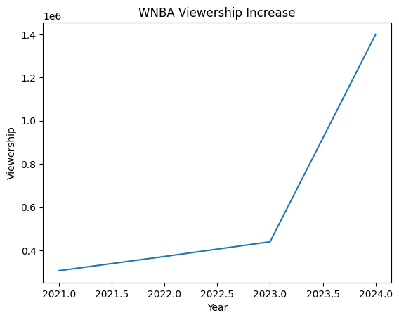

```python
plt.plot(df['Year'], df['Viewership'])
plt.xlabel('Year')
plt.ylabel('Viewership')
plt.title('WNBA Viewership Increase')
plt.show()
```

*Note: only the first five games of 2024 are included in this data set. This is a measurement of the REGULAR SEASON games, and does not include the playoffs.

*From 2023 to 2024 WNBA veiwership increased largely due to the popularity of rookies Angel Reese, and Caitlin Clark

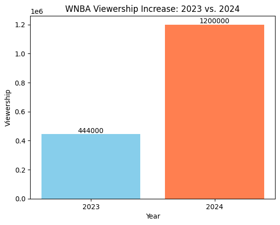

```python
import matplotlib.pyplot as plt
import pandas as pd

# Sample WNBA viewership data
data = {
    'Year': [2023, 2024],
    'Viewership': [444000, 1200000]
}

df = pd.DataFrame(data)

# Create the bar chart
plt.bar(df['Year'], df['Viewership'], color=['skyblue', 'coral'])  # Different colors for emphasis
plt.xlabel('Year')
plt.ylabel('Viewership')
plt.title('WNBA Viewership Increase: 2023 vs. 2024')
plt.xticks(df['Year'])  # Ensure only 2023 and 2024 are on the x-axis

# Add data labels for clarity
for i, v in enumerate(df['Viewership']):
    plt.text(df['Year'][i], v + 10000, str(v), ha='center', color='black')

plt.show()
```

*Comparing the 2023 and 2024 Wnba seasons the average veiwership per game for the regular season increased by 170%

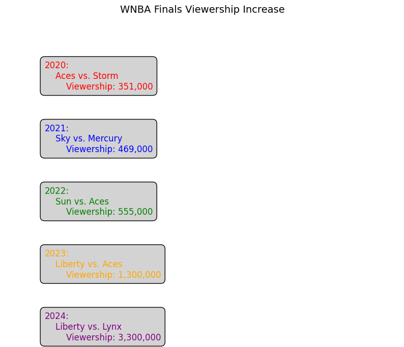

```python
import matplotlib.pyplot as plt
import pandas as pd

# WNBA Finals viewership data
data = {
    'Year': [2020, 2021, 2022, 2023, 2024],
    'Viewership': [351000, 469000, 555000, 1300000, 3300000],
    'Matchup': ['Aces vs. Storm', 'Sky vs. Mercury', 'Sun vs. Aces', 'Liberty vs. Aces', 'Liberty vs. Lynx']
}

df = pd.DataFrame(data)

# Assign colors to each matchup
colors = {'Aces vs. Storm': 'red',
          'Sky vs. Mercury': 'blue',
          'Sun vs. Aces': 'green',
          'Liberty vs. Aces': 'orange',
          'Liberty vs. Lynx': 'purple'}

# Create the list visual
fig, ax = plt.subplots(figsize=(10, 8))

# Remove axes
ax.axis('off')

# Add list items with color coding and complex formatting
y_pos = 0.8  # Starting y-position
for i in range(len(df)):
    text = f"{df['Year'][i]}:\n"  # Add newline for year
    text += f"{' ' * 4}{df['Matchup'][i]}\n"  # Indent matchup
    text += f"{' ' * 8}Viewership: {df['Viewership'][i]:,}"  # Indent viewership
    ax.text(0.1, y_pos, text, color=colors[df['Matchup'][i]], fontsize=12,
            bbox=dict(facecolor='lightgray', edgecolor='black', boxstyle='round,pad=0.5'))  # Add box
    y_pos -= 0.2  # Adjust y-position for next item with more spacing

# Title
ax.set_title('WNBA Finals Viewership Increase', fontsize=14, pad=20)

plt.show()
```

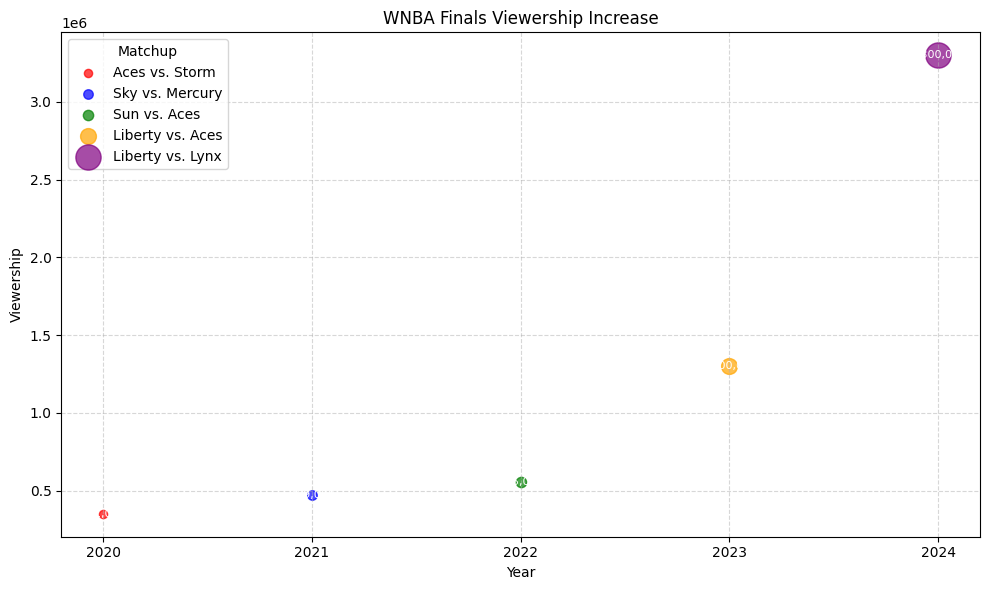

```python
import matplotlib.pyplot as plt
import pandas as pd

# WNBA Finals viewership data
data = {
    'Year': [2020, 2021, 2022, 2023, 2024],
    'Viewership': [351000, 469000, 555000, 1300000, 3300000],
    'Matchup': ['Aces vs. Storm', 'Sky vs. Mercury', 'Sun vs. Aces', 'Liberty vs. Aces', 'Liberty vs. Lynx']
}

df = pd.DataFrame(data)

# Assign colors to each matchup
colors = {'Aces vs. Storm': 'red',
          'Sky vs. Mercury': 'blue',
          'Sun vs. Aces': 'green',
          'Liberty vs. Aces': 'orange',
          'Liberty vs. Lynx': 'purple'}

# Create the bubble chart
plt.figure(figsize=(10, 6))
for i in range(len(df)):
    plt.scatter(df['Year'][i], df['Viewership'][i],
                s=df['Viewership'][i] / 10000,
                color=colors[df['Matchup'][i]],
                alpha=0.7,
                label=df['Matchup'][i])

    # Add viewership as text inside the bubble
    plt.text(df['Year'][i], df['Viewership'][i],
             f"{df['Viewership'][i]:,}",  # Format with commas for thousands separator
             ha='center', va='center', color='white', fontsize=8)  # Adjust fontsize as needed

plt.xlabel('Year')
plt.ylabel('Viewership')
plt.title('WNBA Finals Viewership Increase')
plt.xticks(df['Year'])
plt.legend(loc='upper left', title='Matchup')

plt.tight_layout()
plt.grid(True, linestyle='--', alpha=0.5)
plt.show()
```

Above we use a bubble chart to convey the wnba FINALS championship game increase of veiwership over the last five years.

FUN FACTS: What some know as the "Caitlin Clark affect" is what people like to use to explain the rise in veiwership across the Wnba. In all reality, it was the combined efforts of this years "Rookie class" that effcted the vieweship at such a massive level!

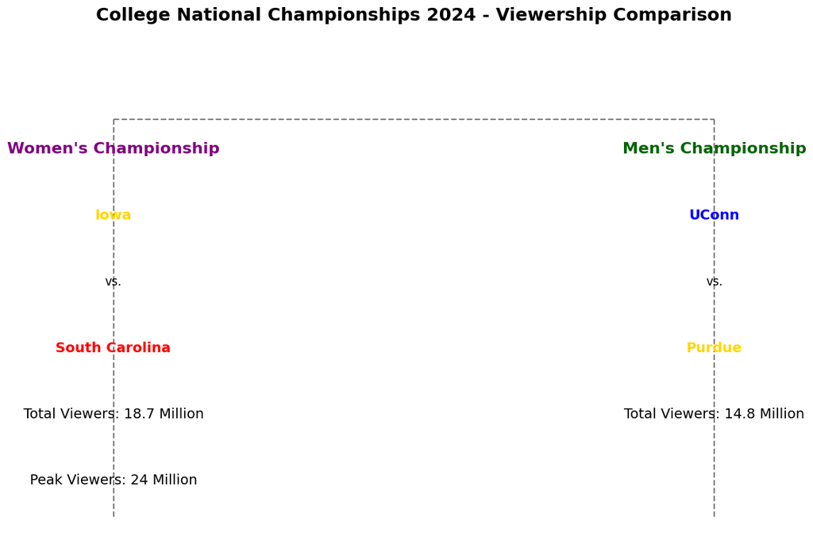

```python
import matplotlib.pyplot as plt

# Create figure and axes
fig, ax = plt.subplots(figsize=(12, 8))

# Remove axes for a cleaner look
ax.axis('off')

# Title
ax.text(0.5, 0.95, "College National Championships 2024 - Viewership Comparison", fontsize=18, ha='center', weight='bold')

# Women's Championship
ax.text(0.25, 0.75, "Women's Championship", fontsize=16, ha='center', color='purple', weight='bold')
ax.text(0.25, 0.65, "Iowa", fontsize=14, ha='center', color='gold', weight='bold')  # Yellow for Iowa
ax.text(0.25, 0.55, "vs.", fontsize=12, ha='center')
ax.text(0.25, 0.45, "South Carolina", fontsize=14, ha='center', color='red', weight='bold')  # Red for South Carolina
ax.text(0.25, 0.35, f"Total Viewers: 18.7 Million", fontsize=14, ha='center', color='black')
ax.text(0.25, 0.25, f"Peak Viewers: 24 Million", fontsize=14, ha='center', color='black')

# Men's Championship
ax.text(0.75, 0.75, "Men's Championship", fontsize=16, ha='center', color='darkgreen', weight='bold')
ax.text(0.75, 0.65, "UConn", fontsize=14, ha='center', color='blue', weight='bold')  # Blue for UConn
ax.text(0.75, 0.55, "vs.", fontsize=12, ha='center')
ax.text(0.75, 0.45, "Purdue", fontsize=14, ha='center', color='gold', weight='bold')  # Gold for Purdue
ax.text(0.75, 0.35, f"Total Viewers: 14.8 Million", fontsize=14, ha='center', color='black')


# Add connecting lines for visual complexity
ax.plot([0.25, 0.75], [0.8, 0.8], color='gray', linestyle='--')  # Horizontal line
ax.plot([0.25, 0.25], [0.8, 0.2], color='gray', linestyle='--')  # Vertical line for women's
ax.plot([0.75, 0.75], [0.8, 0.2], color='gray', linestyle='--')  # Vertical line for men's

plt.show()
```

2024: For the first time in the history of college basketball the Womens College National championship drew more veiwers than the mens did! This is relevant because the popularity began here. The "rookies" brought over a massive following when they were drafted, and were the main reason the W's veiwership increased on such a massiv level.

Citing Sources: (APA Format)

NCAA.org. (2024, April 12). The magic of march: Men’s and women’s tournaments highlight continued growth, impact of college basketball. https://www.ncaa.org/news/2024/4/12/media-center-the-magic-of-march-mens-and-womens-tournaments-highlight-continued-growth-impact-of-college-basketball.aspx#:~:text=For%20the%20first%20time%2C%20the,peaking%20at%2024%20million%20viewers.

Schei, G. S., Høigaard, R., Erikstad, M. K., Ivarsson, A., & Haugen, T. (2023, July 3). Identity leadership and cohesion in Elite Sport: The mediating role of intra-team communication. Heliyon. https://pmc.ncbi.nlm.nih.gov/articles/PMC10345360/

Brito, S. (2024, October 28). The 2024 WNBA season delivers record viewership across ESPN platforms. ESPN Press Room U.S. https://espnpressroom.com/us/press-releases/2024/10/the-2024-wnba-season-delivers-record-viewership-across-espn-platforms/

OpenAI. (2023). ChatGPT (Mar 14 version) [Large language model]. https://chat.openai.com/chat